# Topic Modeling

Joao Macosso, Odomero, Koki

2023-02-06

# Required Libraries

```r
library(readr)
library(dplyr)
library(pander)
library(tm)
library(SnowballC)
library(textstem)
library(magrittr)
library(tidytext)
library(tm)
library(topicmodels)
library(tidyverse)
library(scales)
library(caret)
library(e1071)
library(pROC)
library(glmnet)
```

## Import some user define functions

```r
source("src/SupportFunctions.R")
```

#NLP

### Read Required Datasets

```r
phone_review_data <- read_csv("data/mobile-phones-20191226-reviews.csv")
brands <- read_csv("data/mobile-phones-20191226-items.csv")

#Merge the dataset to include brands
phone_review_data <- phone_review_data %>% left_join(brands %>% select(asin,brand),
                                by = "asin")
# We keep only the rows with available brand
phone_review_data <- phone_review_data %>% filter(!is.na(brand))
```

The file is too large, it contains more than 30K reviews, rendering takes too much of the memory, Therefore only the 15% of it is will be used

```r
# The file is too large, rendering takes too much of the memory,
# Therefore only the 15% of it is will be used
set.seed(10)
selection <- createDataPartition(phone_review_data$rating, p=0.15, list=FALSE)
phone_review_data <- phone_review_data[selection,]
```

# Classification

Our aim is to predict the rating of a based on a given review comement by the user, we will se binary classifier, therefore, we treat reviews lower or equal 2 as 0(Bad review), reviews larger or equal 4 as 1, good reviews.

```r
phone_review_data = phone_review_data %>% filter(rating != 3) %>%
  mutate(rating = ifelse(rating <= 2, 0, 1))

# first put smstext in tm corpus format
corpus <- VCorpus(VectorSource(phone_review_data$body))
# standardize to lowercase
corpus <- tm_map(corpus, content_transformer(tolower))
# remove tm stopwords
corpus <- tm_map(corpus, removeWords, stopwords())
# standardize whitespaces
corpus <- tm_map(corpus, stripWhitespace)
# remove punctuation
corpus <- tm_map(corpus, removePunctuation)
#stem
corpus <- tm_map(corpus, stemDocument)

corpus <- tm_map(corpus, removeWords, stopwords("english"))
corpus <- tm_map(corpus, removeWords, stopwords("spanish"))
```

## Get the term matrix

```r
dtm <- DocumentTermMatrix(corpus)
dtm
```

```
## <<DocumentTermMatrix (documents: 9466, terms: 11019)>>
## Non-/sparse entries: 194470/104111384
## Sparsity           : 100%
## Maximal term length: 221
## Weighting          : term frequency (tf)
```

```r
frequent <- findFreqTerms(dtm, 10)
head(frequent,8)
```

```
## [1] "’ll"   "’re"   "’ve"   "100"   "1000"  "1010"  "1080p" "128"
```

## Clean the data

```r
toSpace <- content_transformer(function (x , pattern ) gsub(pattern, " ", x))
corpus <-tm_map(corpus,toSpace,"\\d.*")
corpus <-tm_map(corpus,toSpace,"ll")
corpus <-tm_map(corpus,toSpace,"re")
corpus <-tm_map(corpus,toSpace,"ve")
corpus <- tm_map(corpus, stripWhitespace)
```

## Split the train test data

```r
set.seed(10)
# set for the original raw data
train_idx <- createDataPartition(phone_review_data$rating, p=0.7, list=FALSE)
train1 <- phone_review_data[train_idx,]
test1 <- phone_review_data[-train_idx,]

# set for the cleaned-up data
train2 <- corpus[train_idx]
test2 <- corpus[-train_idx]
```

```r
dtm2 <- DocumentTermMatrix(corpus, list(global = c(2, Inf), dictionary = frequent))
inspect(dtm2)
```

```
## <<DocumentTermMatrix (documents: 9466, terms: 1995)>>
## Non-/sparse entries: 77383/18807287
## Sparsity           : 100%
## Maximal term length: 12
## Weighting          : term frequency (tf)
## Sample             :
##       Terms
## Docs   batteri get good just like new one phone use work
##   1022       0   1    0    2    1   0   1     7   0    0
##   1473       0   2    2    8    1   0   2     7   1    2
##   2611       0   0    0    0    0   2   2     8   0    4
##   3          0   0    0    1    0   0   0     5   2    0
##   5442       1   2    0    3    0   0   0     3   4    1
##   5451       2   1    0    3    2   1   1    12   2    0
##   6088       0   0    0    0    2   0   3    10   8    3
##   637        1   4    0    4    1   2   2     4   2    1
##   7338       1   2    1    2    3   0   4     9   4    2
##   8930       0   1    1    3    4   1   0     6   6    0
```

```r
dict2 <- findFreqTerms(dtm2, lowfreq=10)
```

```r
# the same apply on train and test sets
phone_train <- DocumentTermMatrix(train2, list(dictionary=dict2))
phone_test <- DocumentTermMatrix(test2, list(dictionary=dict2))
```

```r
# compare number of terms
dtm
```

```
## <<DocumentTermMatrix (documents: 9466, terms: 11019)>>
## Non-/sparse entries: 194470/104111384
## Sparsity           : 100%
## Maximal term length: 221
## Weighting          : term frequency (tf)
```

```r
dtm2
```

```
## <<DocumentTermMatrix (documents: 9466, terms: 1995)>>
## Non-/sparse entries: 77383/18807287
## Sparsity           : 100%
## Maximal term length: 12
## Weighting          : term frequency (tf)
```

```r
phone_train
```

```
## <<DocumentTermMatrix (documents: 6627, terms: 1044)>>
## Non-/sparse entries: 51451/6867137
## Sparsity           : 99%
## Maximal term length: 11
## Weighting          : term frequency (tf)
```

```r
phone_test
```

```
## <<DocumentTermMatrix (documents: 2839, terms: 1044)>>
## Non-/sparse entries: 22812/2941104
## Sparsity           : 99%
## Maximal term length: 11
## Weighting          : term frequency (tf)
```

```r
convert_counts <- function(x) {
  x <- ifelse(x > 0, 1, 0)
}

phone_train <- phone_train %>% apply(MARGIN=2, FUN=convert_counts)
phone_test <- phone_test %>% apply(MARGIN=2, FUN=convert_counts)

# make it back to a data frame
phone_train <- as.data.frame(phone_train)
phone_test <- as.data.frame(phone_test)
```

```r
str(phone_train)
```

```
## 'data.frame':    6627 obs. of  1044 variables:
##  $ abil       : num  0 0 0 0 0 0 0 0 0 0 ...
##  $ abl        : num  0 0 0 0 0 0 0 0 0 0 ...
##  $ absolut    : num  0 0 0 0 0 0 0 0 0 0 ...
##  $ accept     : num  0 0 0 0 0 0 0 0 0 0 ...
##  $ access     : num  0 0 0 0 0 0 0 0 0 0 ...
##  $ accessori  : num  0 0 0 0 0 0 0 0 0 0 ...
##  $ accident   : num  0 0 0 0 0 0 0 0 0 0 ...
##  $ account    : num  0 0 0 0 0 0 0 0 0 0 ...
##  $ accur      : num  0 0 0 0 0 0 0 0 0 0 ...
##  $ across     : num  0 0 0 0 0 0 0 0 0 0 ...
##  $ act        : num  0 0 0 0 0 0 0 0 0 0 ...
##  $ activ      : num  0 0 0 0 0 0 0 0 0 0 ...
##  $ actual     : num  0 0 0 0 0 0 0 0 0 0 ...
##  $ adapt      : num  0 0 0 0 0 0 0 0 0 0 ...
```

[output cut: 86 more lines]

```r
# prepare the data
phone_train1 <- cbind(label=factor(train1$rating), phone_train)
phone_test1 <- cbind(label=factor(test1$rating), phone_test)

phone_train1 <-as.data.frame(phone_train1)
phone_test1 <-as.data.frame(phone_test1)
```

## Modeling

### Logistic regression

```r
phone_rating_model <- glm(label~.,
                          data=phone_train1,
                          family = "binomial")
```

```r
# Predict test data based on model
predict_reg <- predict(phone_rating_model,
                       na.omit(phone_test1), type = "response")

# Changing probabilities
predict_reg <- ifelse(predict_reg >0.5, 1, 0)

# Evaluating model accuracy
# using confusion matrix
table(phone_test1$label, predict_reg, dnn=c("Actual", "Predicted"))
```

```
##       Predicted
## Actual    0    1
##      0  416  356
##      1  193 1874
```

```r
#summary(phone_rating_model)
```

```r
confMatrix1 <- confusionMatrix(factor(predict_reg), factor(phone_test1$label), positive = "1")
confMatrix1
```

```
## Confusion Matrix and Statistics
##
##           Reference
## Prediction    0    1
##          0  416  193
##          1  356 1874
##
##                Accuracy : 0.8066
##                  95% CI : (0.7916, 0.821)
##     No Information Rate : 0.7281
##     P-Value [Acc > NIR] : < 2.2e-16
##
##                   Kappa : 0.477
##
##  Mcnemar's Test P-Value : 4.712e-12
##
##             Sensitivity : 0.9066
##             Specificity : 0.5389
##          Pos Pred Value : 0.8404
##          Neg Pred Value : 0.6831
##              Prevalence : 0.7281
##          Detection Rate : 0.6601
##    Detection Prevalence : 0.7855
##       Balanced Accuracy : 0.7227
##
##        'Positive' Class : 1
##
```

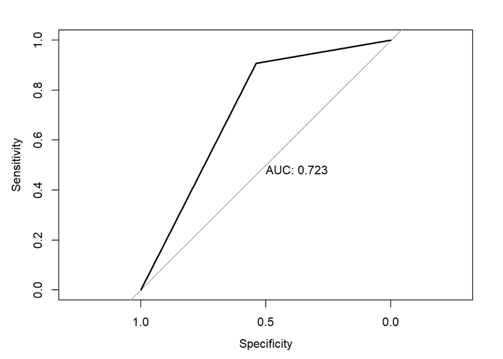

```r
# ROC-AUC Curve

test_roc = roc(phone_test1$label ~ predict_reg, plot = TRUE, print.auc = TRUE)
```

```r
as.numeric(test_roc$auc)
```

```
## [1] 0.722744
```

Our logistic regression did not converge, this is most likely due to large sparsity of the data and possibly multicollinearity, Let us try to address these issues by using logistic regression with penalizations, we are going to use Lasso for regularization

### Lasso

First lets convert the ata into matrix

```r
X <- phone_train1 %>% select(-label) %>% as.matrix()
Y <- as.matrix(phone_train1$label)
XTest <- as.matrix(phone_test1 %>% select(-label))
```

Generally, the purpose of regularization is to balance accuracy and simplicity. This means, a model with the smallest number of predictors that also gives a good accuracy. To this end, the function cv.glmnet() finds also the value of lambda that gives the simplest model but also lies within one standard error of the optimal value of lambda

```r
cv.lasso <- cv.glmnet(X, Y, alpha = 1, family = "binomial")
print(paste("Optimal lambda:", cv.lasso$lambda.min))
```

```
## [1] "Optimal lambda: 0.00386398889688531"
```

```r
# Fit the final model on the training data
model_lasso <- glmnet(X, Y, alpha = 1, family = "binomial",
                lambda = cv.lasso$lambda.min)
```

```r
# Predict test data based on model
predict_lasso_reg <- predict(model_lasso,
                             XTest,
                       type = "response")

# Changing probabilities
predict_lasso_reg <- ifelse(predict_lasso_reg >0.5, 1, 0)

# Evaluating model accuracy
# using confusion matrix
confMatrix1_lasso <- confusionMatrix(factor(predict_lasso_reg), factor(phone_test1$label), positive = "1")
confMatrix1_lasso
```

```
## Confusion Matrix and Statistics
##
##           Reference
## Prediction    0    1
##          0  366   87
##          1  406 1980
##
##                Accuracy : 0.8263
##                  95% CI : (0.8119, 0.8401)
##     No Information Rate : 0.7281
##     P-Value [Acc > NIR] : < 2.2e-16
##
##                   Kappa : 0.4962
##
##  Mcnemar's Test P-Value : < 2.2e-16
##
##             Sensitivity : 0.9579
##             Specificity : 0.4741
##          Pos Pred Value : 0.8298
##          Neg Pred Value : 0.8079
##              Prevalence : 0.7281
##          Detection Rate : 0.6974
##    Detection Prevalence : 0.8404
##       Balanced Accuracy : 0.7160
##
##        'Positive' Class : 1
##
```

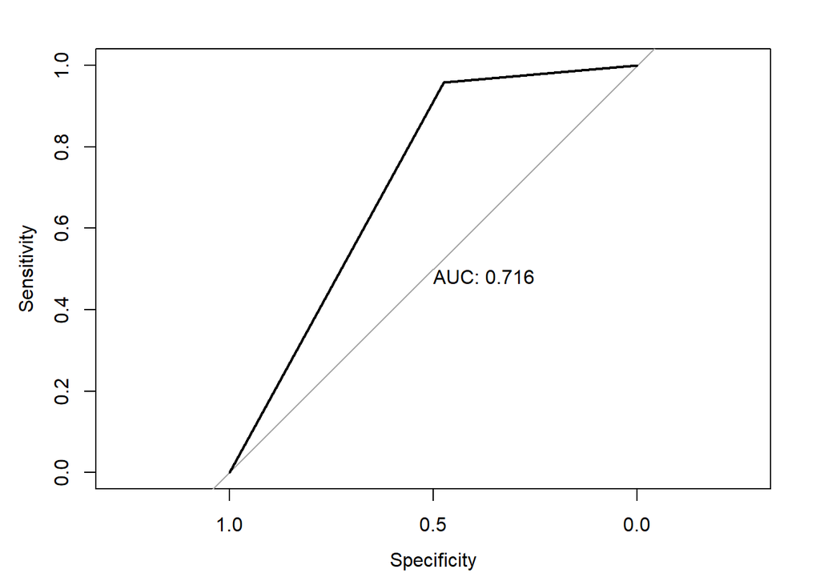

```r
# ROC-AUC Curve

test_roc_lasso = roc(phone_test1$label ~ as.vector(predict_lasso_reg),
                     plot = TRUE, print.auc = TRUE)
```

```r
as.numeric(test_roc_lasso$auc)
```

```
## [1] 0.7160016
```

We can see that most metrix have improved a bit such as accuracy, Sensitivity, while specifity and aaaaaaauc is worse now. Also noting that our data is highly unbalanced with most reviews having rating 4 or 5, so it is very difficult to get a good model, an alternative would be to balance the dataset.